# Mid-Project Group 3

```r
# Read CSV from a URL

# Import the dataset from Google Drive
url <- "https://drive.google.com/uc?export=download&id=1d8bEgUisDBY-2qC9Csy4qm3d_th_l9PN"
df <- read.csv(url, na.strings = c("NA", "", "NULL"))

# View the first few rows of the dataframe to check the import
head(df)
```

|  | screen_time_hours | bedtime_hour | age | app_type_most_used | stress_level |
| --- | --- | --- | --- | --- | --- |
| 1 | 6.99 | 20 | 22 | Entertainment | Moderate |
| 2 | 5.72 | 20 | NA | Gaming | Low |
| 3 | 7.30 | 20 | 25 | Educational | Low |
| 4 | 9.05 | 23 | 20 | Social | Moderate |
| 5 | 5.53 | NA | 18 | NA | Moderate |
| 6 | 5.53 | 22 | 30 | Educational | High |

```r
#View the summary of the dataset
summary(df)
```

```
##  screen_time_hours  bedtime_hour        age        app_type_most_used
##  Min.   :-0.480    Min.   :20.00   Min.   :18.00   Length:1000
##  1st Qu.: 4.723    1st Qu.:21.00   1st Qu.:21.00   Class :character
##  Median : 6.050    Median :22.00   Median :24.00   Mode  :character
##  Mean   : 6.191    Mean   :22.02   Mean   :23.91
##  3rd Qu.: 7.348    3rd Qu.:23.00   3rd Qu.:27.00
##  Max.   :22.810    Max.   :24.00   Max.   :30.00
##  NA's   :50        NA's   :50      NA's   :50
##  stress_level
##  Length:1000
##  Class :character
##  Mode  :character
##
##
##
##
```

## Data Exploration

Univariate Analysis

HISTOGRAM (NUMERIC)

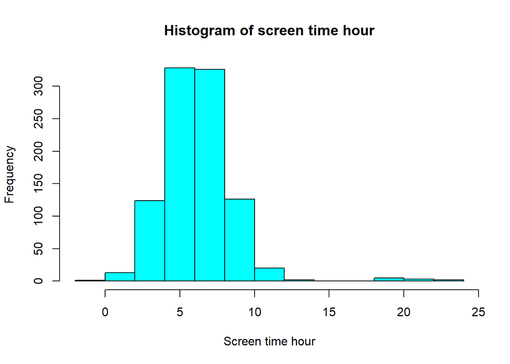

```r
# Histogram of Screen time hours
hist(df$screen_time_hours,
     main="Histogram of screen time hour",
     col="cyan",
     xlab="Screen time hour",
     border="black")
```

Observation: Most users had screen time between 3 and 8 hours. Few users had very high usage above 10 hours.

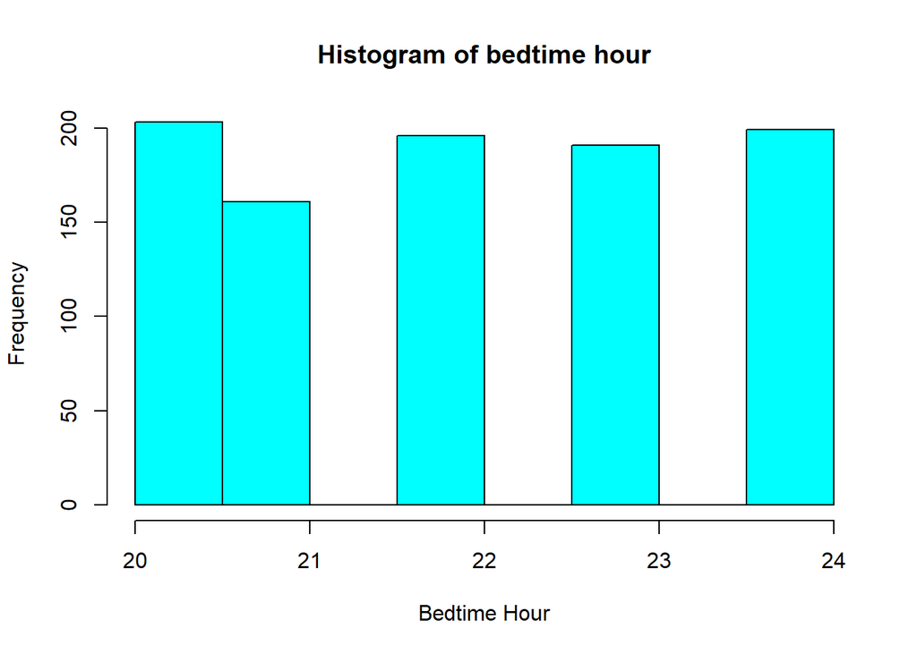

```r
# Histogram of   bedtime_hour
hist(df$  bedtime_hour,
     main="Histogram of bedtime hour",
     col="cyan",
     xlab="Bedtime Hour",
     border="black")
```

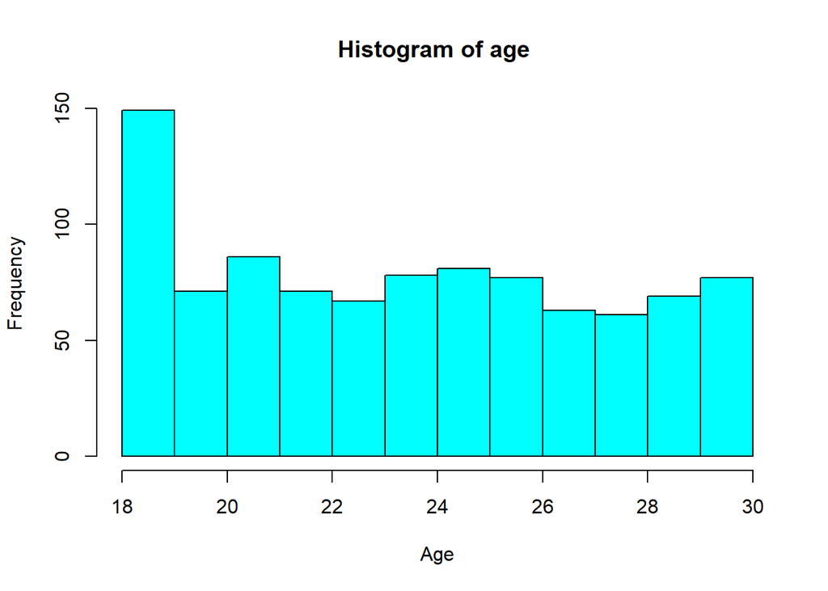

```r
# Histogram of age
hist(df$   age ,
     main="Histogram of age ",
     col="cyan",
     xlab="Age",
     border="black")
```

the most common users are around age of 18

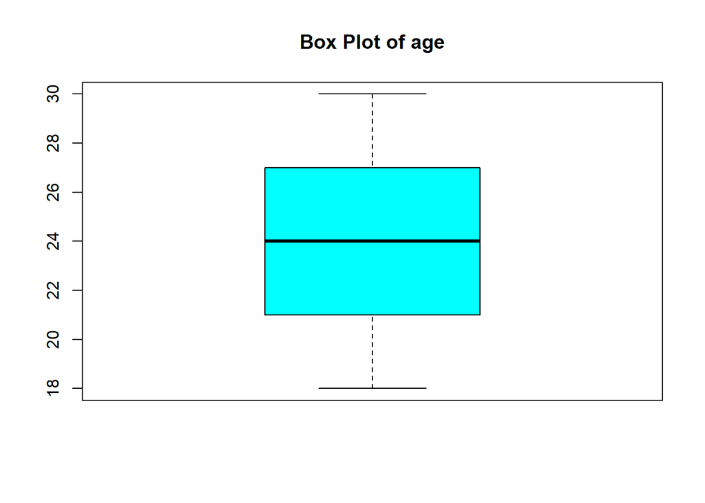

```r
# Boxplot
boxplot(df$age,
        main="Box Plot of age",
        col="cyan")
```

Mostly normal, no outliers spotted

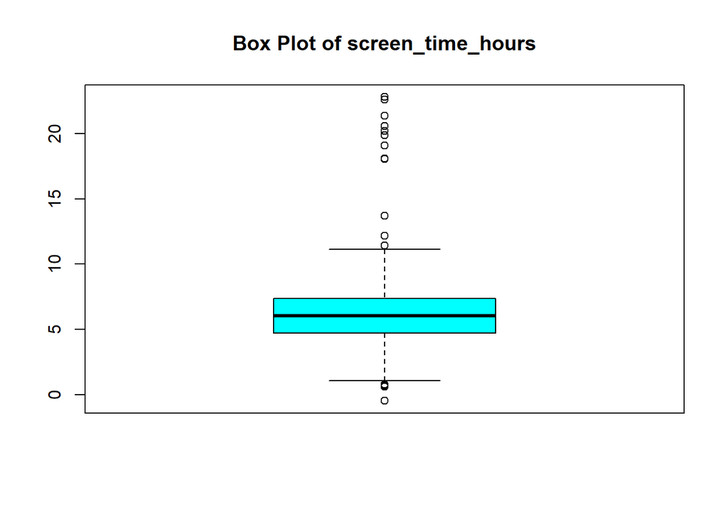

```r
# Boxplot
boxplot(df$screen_time_hours,
        main="Box Plot of screen_time_hours",
        col="cyan")
```

Outliers exist (high screen time)

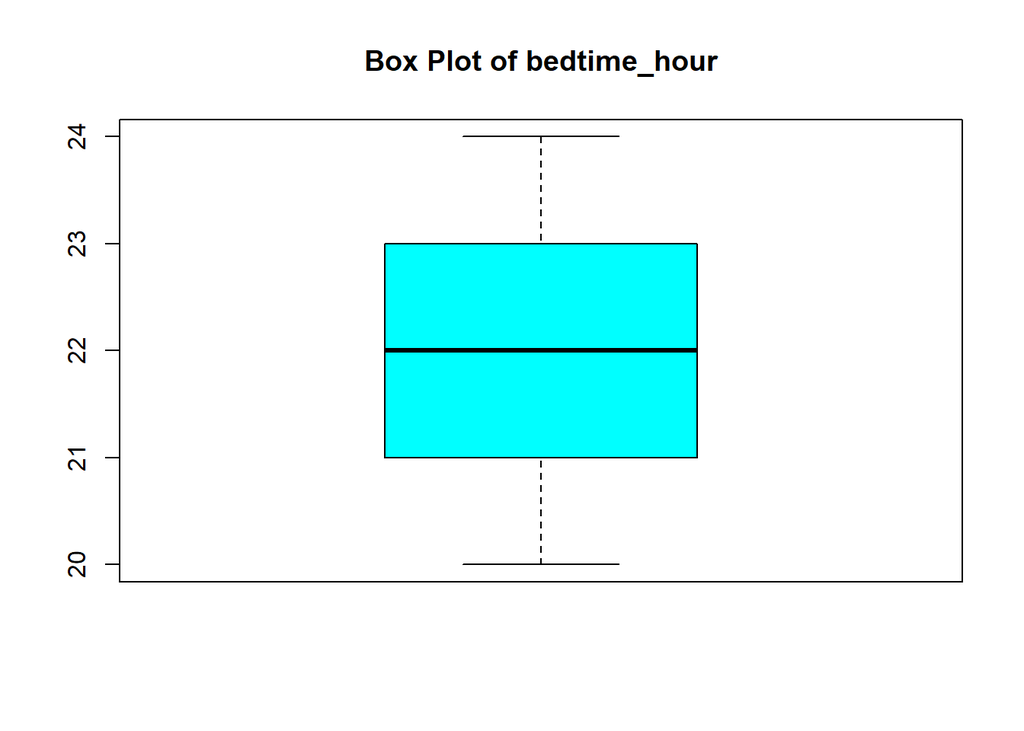

```r
boxplot(df$bedtime_hour,
        main="Box Plot of bedtime_hour",
        col="cyan")
```

Mostly normal, no outliers spotted

Exploring Categorical Data

```r
 #Count
table(df$app_type_most_used)
```

```
##
##   Educational Entertainment        Gaming        Social       Utility
##           200           181           190           185           194
```

```r
#Count of Home Country
table(df$stress_level)
```

```
##
##     High      Low Moderate
##      188      289      473
```

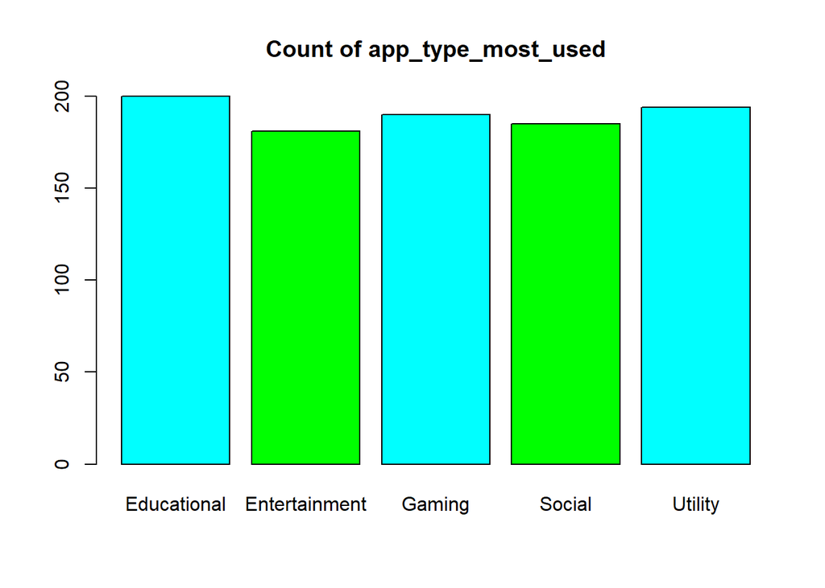

```r
# Bar plot
barplot(table(df$app_type_most_used),
        main="Count of app_type_most_used",
        col=c("cyan", "green"))
```

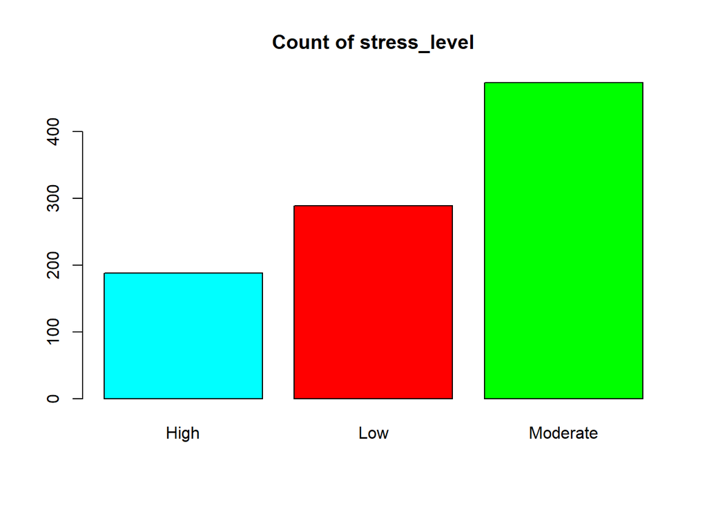

```r
# Bar plot
barplot(table(df$stress_level),
        main="Count of stress_level",
        col=c("cyan","red", "green"))
```

Stress level moderate is highly distributed

Multivariate plots

Scatter plot, pair plot and correlation matrix have been displayed to observe different result

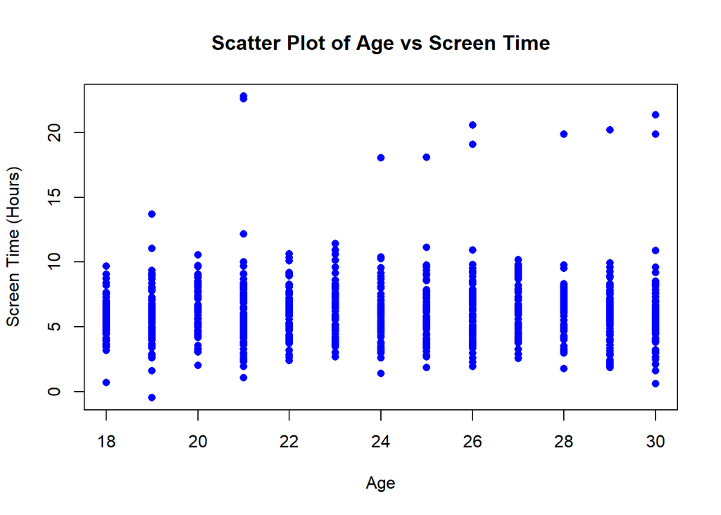

```r
plot(df$age, df$screen_time_hours,
     main = "Scatter Plot of Age vs Screen Time",
     xlab = "Age",
     ylab = "Screen Time (Hours)",
     col = "blue",
     pch = 16)
```

outliers spotted here

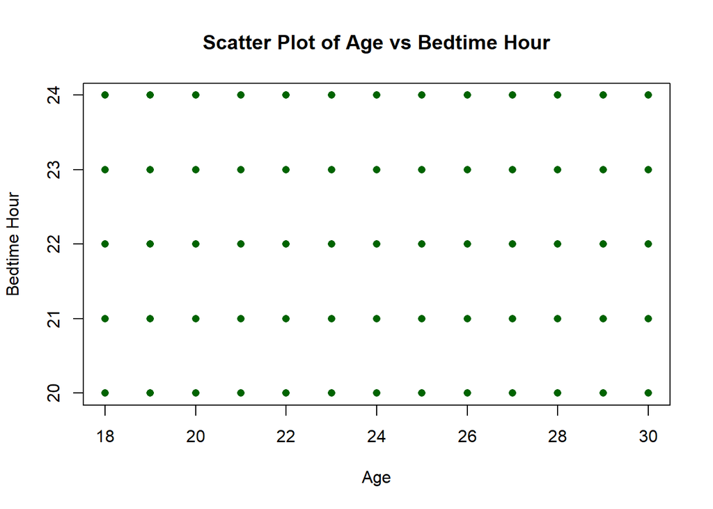

```r
plot(df$age, df$bedtime_hour,
     main = "Scatter Plot of Age vs Bedtime Hour",
     xlab = "Age",
     ylab = "Bedtime Hour",
     col = "darkgreen",
     pch = 16)
```

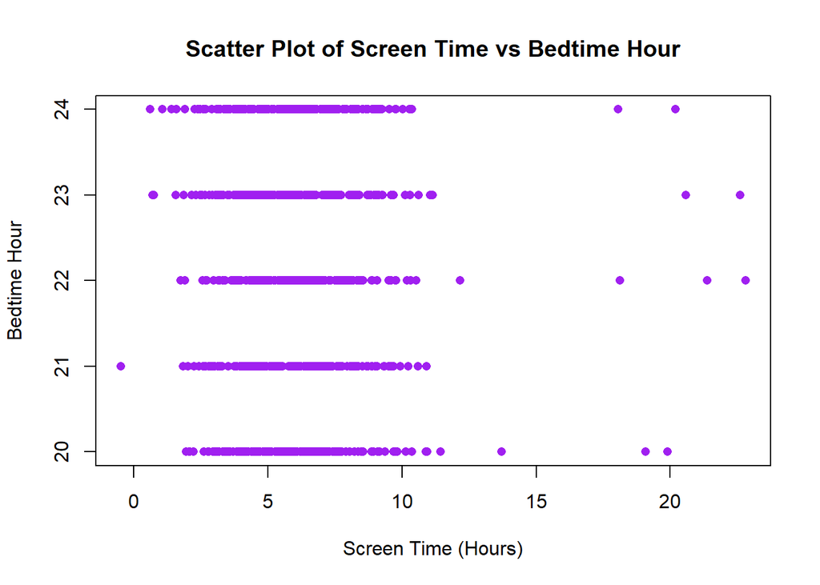

```r
plot(df$screen_time_hours, df$bedtime_hour,
     main = "Scatter Plot of Screen Time vs Bedtime Hour",
     xlab = "Screen Time (Hours)",
     ylab = "Bedtime Hour",
     col = "purple",
     pch = 16)
```

Box Plot (Numeric vs. Categorical)

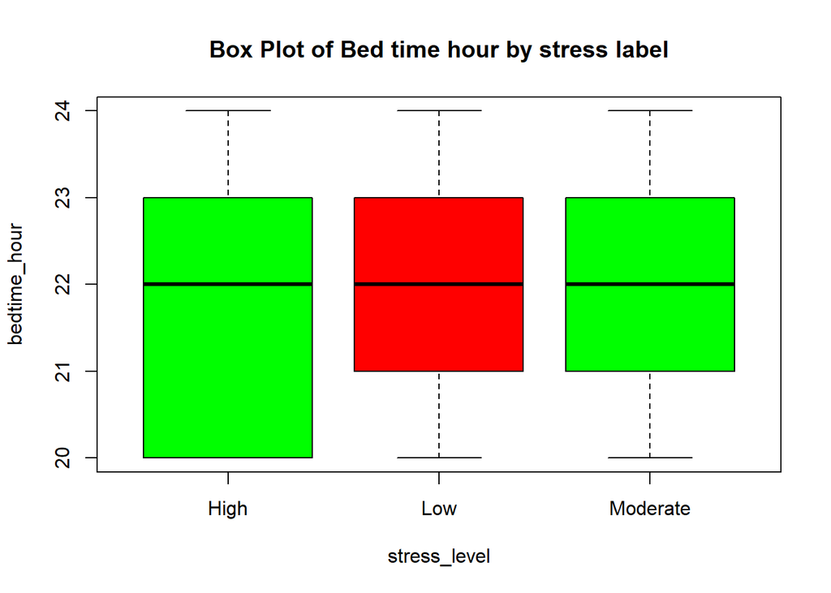

```r
boxplot(bedtime_hour
 ~ stress_level, data=df,
        main="Box Plot of Bed time hour by stress label",
        col=c("green", "red"))
```

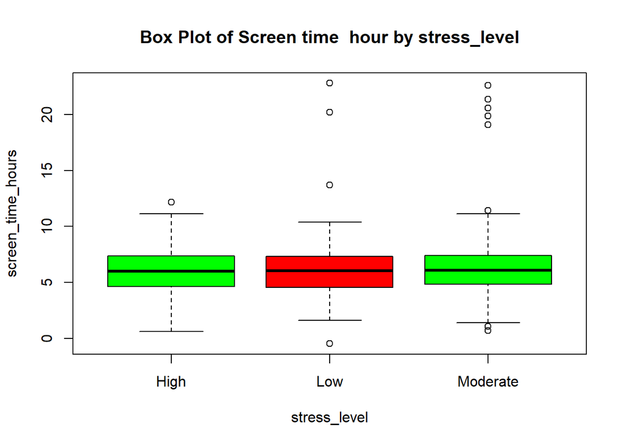

```r
boxplot(screen_time_hours ~ stress_level, data=df,
        main="Box Plot of Screen time  hour by stress_level",
        col=c("green", "red"))
```

In this Box plot more outliers were spotted in moderate stress level.

##Check for missing values

```r
is.na(df)
```

[output not shown]

[output cut: 986 more lines]

Count missing values per column

```r
colSums(is.na(df))
```

```
##  screen_time_hours       bedtime_hour                age app_type_most_used
##                 50                 50                 50                 50
##       stress_level
##                 50
```

Check total missing values

```r
sum(is.na(df))
```

```
## [1] 250
```

250 missing values observed Replace NA with the Median of the Column 1,2,3

```r
# Replace NA with the Median of each column
df$screen_time_hours[is.na(df$screen_time_hours)] <- median(df$screen_time_hours, na.rm = TRUE)
df$bedtime_hour[is.na(df$bedtime_hour)] <- median(df$bedtime_hour, na.rm = TRUE)
df$age[is.na(df$age)] <- median(df$age, na.rm = TRUE)

# Print the updated dataframe
print(df[c("screen_time_hours", "bedtime_hour", "age")])
```

```
##      screen_time_hours bedtime_hour age
## 1                 6.99           20  22
## 2                 5.72           20  24
## 3                 7.30           20  25
## 4                 9.05           23  20
## 5                 5.53           22  18
## 6                 5.53           22  30
## 7                 9.16           24  24
## 8                 7.53           22  30
## 9                 5.06           20  22
## 10                7.09           22  22
## 11                5.07           20  24
## 12                5.07           23  18
## 13                6.48           22  25
## 14                2.17           23  29
```

[output cut: 986 more lines]

Replace Categorical column app_type_most_used NA with Mode

```r
# Replace missing values in 'app_type_most_used' with the mode
df$app_type_most_used[is.na(df$app_type_most_used)] <-
  names(sort(table(df$app_type_most_used), decreasing = TRUE))[1]

# Print only the 'app_type_most_used' column
print(df[c("app_type_most_used")])
```

```
##      app_type_most_used
## 1         Entertainment
## 2                Gaming
## 3           Educational
## 4                Social
## 5           Educational
## 6           Educational
## 7                Gaming
## 8           Educational
## 9           Educational
## 10               Gaming
## 11        Entertainment
## 12        Entertainment
## 13               Social
## 14               Social
```

[output cut: 986 more lines]

Remove rows of missing values in Target column stress_level

```r
# Remove rows where 'stress_level' is NA
df <- subset(df, !is.na(stress_level))


# Print the 'stress_level' column as part of the data frame
print(df[c("stress_level")])
```

```
##      stress_level
## 1        Moderate
## 2             Low
## 3             Low
## 4        Moderate
## 5        Moderate
## 6            High
## 7             Low
## 8        Moderate
## 9            High
## 10           High
## 11       Moderate
## 12       Moderate
## 13       Moderate
## 14           High
```

[output cut: 936 more lines]

```r
# Check for missing values in the final dataset (df)
missing_values <- sum(is.na(df))

# Print the result
if(missing_values > 0) {
  cat("There are", missing_values, "missing values in the dataset.\n")
} else {
  cat("No missing values in the dataset.\n")
}
```

```
## No missing values in the dataset.
```

```r
class(df)
```

```
## [1] "data.frame"
```

Univariate analysis (Density plots)

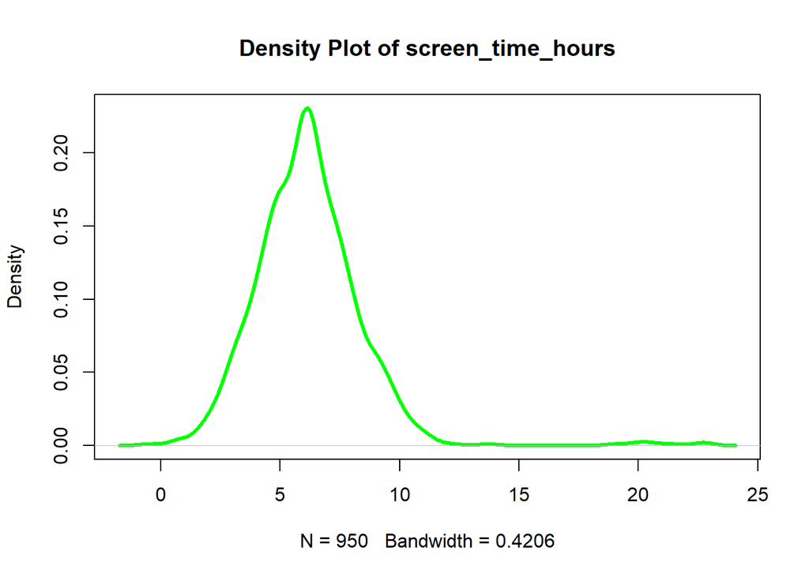

```r
# Density Plot
plot (density(df$  screen_time_hours),
     main="Density Plot of screen_time_hours",
     col="GREEN",
     lwd=3)
```

peaks around 5–7 hours

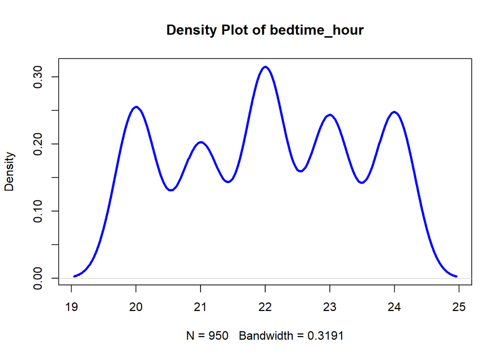

```r
plot(density(df$bedtime_hour),
     main="Density Plot of bedtime_hour",
     col="BLUE",
     lwd=3)
```

Peaks around 22:00

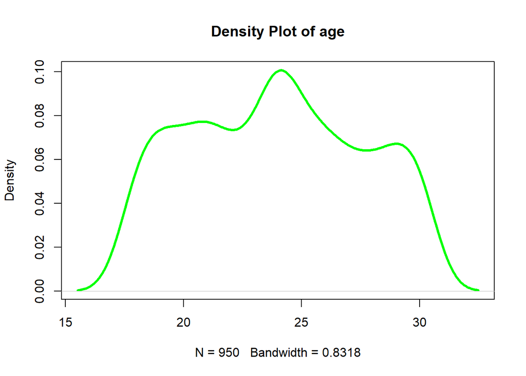

```r
# Density Plot
plot(density(df$age),
     main="Density Plot of age",
     col="green",
     lwd=3)
```

Most common user are between age of 20 to 25

```r
# Correlation matrix
correlation_matrix <- cor(df[, c("screen_time_hours", "bedtime_hour", "age")], use = "complete.obs")
print(correlation_matrix)
```

```
##                   screen_time_hours bedtime_hour        age
## screen_time_hours        1.00000000  -0.01265682 0.01008000
## bedtime_hour            -0.01265682   1.00000000 0.03868249
## age                      0.01008000   0.03868249 1.00000000
```

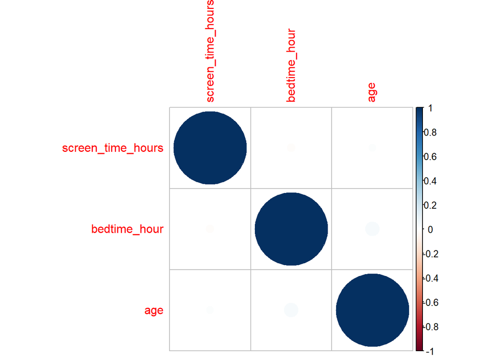

```r
# Plot the correlation matrix using corrplot
library(corrplot)
corrplot(correlation_matrix, method = "circle")
```

Pair plot of numerical columns

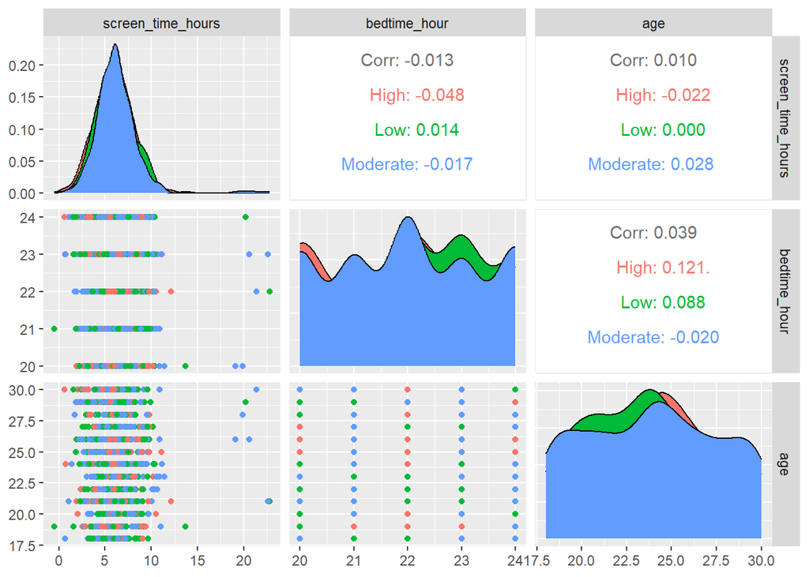

```r
# Load the GGally package for pair plots
library(GGally)
# Create the pair plot with color by 'stress_level' (target categorical variable)
ggpairs(df[, c("screen_time_hours", "bedtime_hour", "age")], aes(color = df$stress_level))
```

```r
# Check for missing values in the final dataset (df)
missing_values <- sum(is.na(df))

# Print the result
if(missing_values > 0) {
  cat("There are", missing_values, "missing values in the dataset.\n")
} else {
  cat("No missing values in the dataset.\n")
}
```

```
## No missing values in the dataset.
```

##Data type conversion using label coding

```r
# Label encoding for 'app_type_most_used' (Nominal)
df$app_type_most_used_encoded <- as.integer(factor(df$app_type_most_used))

# Label encoding for 'stress_level' (Ordinal)
df$stress_level_encoded <- as.integer(factor(df$stress_level))

# Print the encoded columns to verify
print(df[c("app_type_most_used_encoded", "stress_level_encoded")])
```

```
##      app_type_most_used_encoded stress_level_encoded
## 1                             2                    3
## 2                             3                    2
## 3                             1                    2
## 4                             4                    3
## 5                             1                    3
## 6                             1                    1
## 7                             3                    2
## 8                             1                    3
## 9                             1                    1
## 10                            3                    1
## 11                            2                    3
## 12                            2                    3
## 13                            4                    3
## 14                            4                    1
```

[output cut: 936 more lines]

##Outlier detection and capping using IQR method

```r
# Function to detect outliers using IQR and return bounds
detect_outliers <- function(x) {
  Q1 <- quantile(x, 0.25, na.rm = TRUE)
  Q3 <- quantile(x, 0.75, na.rm = TRUE)
  IQR_value <- Q3 - Q1
  lower_bound <- Q1 - 1.5 * IQR_value
  upper_bound <- Q3 + 1.5 * IQR_value

  # Return a list with outlier detection and bounds
  return(list(outliers = x < lower_bound | x > upper_bound,
              lower_bound = lower_bound,
              upper_bound = upper_bound))
}

# Detect outliers for each column and get bounds
screen_time_outliers <- detect_outliers(df$screen_time_hours)
bedtime_outliers <- detect_outliers(df$bedtime_hour)
age_outliers <- detect_outliers(df$age)

# Count the number of outliers for each column
outliers_screen_time_count <- sum(screen_time_outliers$outliers)
outliers_bedtime_count <- sum(bedtime_outliers$outliers)
outliers_age_count <- sum(age_outliers$outliers)

# Print the count of outliers in each column
print(paste("Number of outliers in screen_time_hours: ", outliers_screen_time_count))
```

```
## [1] "Number of outliers in screen_time_hours:  18"
```

```r
print(paste("Number of outliers in bedtime_hour: ", outliers_bedtime_count))
```

```
## [1] "Number of outliers in bedtime_hour:  0"
```

```r
print(paste("Number of outliers in age: ", outliers_age_count))
```

```
## [1] "Number of outliers in age:  0"
```

```r
# Replace outliers with bounds for 'screen_time_hours'
df$screen_time_hours[df$screen_time_hours < screen_time_outliers$lower_bound] <- screen_time_outliers$lower_bound
df$screen_time_hours[df$screen_time_hours > screen_time_outliers$upper_bound] <- screen_time_outliers$upper_bound

# Print outliers for 'screen_time_hours' column
print(df$screen_time_hours[screen_time_outliers$outliers])
```

```
##  [1]  1.11875 10.98875 10.98875 10.98875  1.11875 10.98875 10.98875 10.98875
##  [9] 10.98875 10.98875  1.11875 10.98875  1.11875 10.98875  1.11875 10.98875
## [17] 10.98875 10.98875
```

##Data transformation (scaling)

```r
# Scale the numerical columns: screen_time_hours, bedtime_hour, and age
df$screen_time_hours_scaled <- scale(df$screen_time_hours)
df$bedtime_hour_scaled <- scale(df$bedtime_hour)
df$age_scaled <- scale(df$age)

# Print the first few rows of the scaled data
print(df[, c("screen_time_hours_scaled", "bedtime_hour_scaled", "age_scaled")])
```

```
##      screen_time_hours_scaled bedtime_hour_scaled  age_scaled
## 1                 0.468062444         -1.44574368 -0.52314104
## 2                -0.188270813         -1.44574368  0.02601254
## 3                 0.628269775         -1.44574368  0.30058932
## 4                 1.532665996          0.70140040 -1.07229461
## 5                -0.286462403         -0.01431429 -1.62144818
## 6                -0.286462403         -0.01431429  1.67347326
## 7                 1.589513759          1.41711509  0.02601254
## 8                 0.747133278         -0.01431429  1.67347326
## 9                -0.529357388         -1.44574368 -0.52314104
## 10                0.519742228         -0.01431429 -0.52314104
## 11               -0.524189410         -1.44574368  0.02601254
## 12               -0.524189410          0.70140040 -1.62144818
## 13                0.204495546         -0.01431429  0.30058932
## 14               -2.022903148          0.70140040  1.39889647
```

[output cut: 936 more lines]

##New Dataset after preprocessing

```r
# Remove the specified columns from the dataframe
df_new <- df[, !names(df) %in% c("screen_time_hours", "bedtime_hour", "age", "screen_time_hours_capped",
                                 "app_type_most_used", "stress_level")]

# Print the cleaned dataframe
print(df_new)
```

```
##      app_type_most_used_encoded stress_level_encoded screen_time_hours_scaled
## 1                             2                    3              0.468062444
## 2                             3                    2             -0.188270813
## 3                             1                    2              0.628269775
## 4                             4                    3              1.532665996
## 5                             1                    3             -0.286462403
## 6                             1                    1             -0.286462403
## 7                             3                    2              1.589513759
## 8                             1                    3              0.747133278
## 9                             1                    1             -0.529357388
## 10                            3                    1              0.519742228
## 11                            2                    3             -0.524189410
## 12                            2                    3             -0.524189410
## 13                            4                    3              0.204495546
## 14                            4                    1             -2.022903148
```

[output cut: 1887 more lines]

```r
# Check for missing values in the final dataset (df)
missing_values <- sum(is.na(df))

# Print the result
if(missing_values > 0) {
  cat("There are", missing_values, "missing values in the dataset.\n")
} else {
  cat("No missing values in the dataset.\n")
}
```

```
## No missing values in the dataset.
```

Recheked again and ensured My dataset has no missing values. All coloumns are properly encoded and removed outliers and scaled.